```python
%%javascript
IPython.OutputArea.prototype._should_scroll = function(lines) {
    return false;
}
```

# Post Goals:

1. Provide a Concise Introduction to Support Vector Machine Regression.
2. Demonstrate how to perform Support Vector Machine Regression using Python's Sklean library.

```python
# to load images for this tutorial
from IPython.display import Image
import os
path = os.getcwd()

# Math libraries
import numpy as np

# Data visualization module
import matplotlib as mpl
import matplotlib.pyplot as plt
mpl.rc('axes', labelsize=14)
mpl.rc('xtick', labelsize=12)
mpl.rc('ytick', labelsize=12)

# Key ML modules
from sklearn.svm import LinearSVR
from sklearn.svm import SVR
```

# Post Overview.

# Introduction to Suppor Vector Machine (SVM).

- Support Vector Machine algorithm is a powerful supervised Machine Learning Models capable of performing
  - Linear classification
  - Nonlinear classification
  - Regression
  - Outlier detection
- SVM is one of the most popular machine learning models and is well suited for classification of complex datasets that are small and medium sized.
- Like logistic regression, support vector machines were designed for binary classification and do not natively support classification tasks with more than two classes.
- In this algorithm, data is plotted in n-dimensional space (where n is number of features you have). Then, we perform classification by finding a decision boundary (aka hyperplane in 3d+) that best differentiates the two classes.
- The objective of the support vector machine algorithm is to find a hyperplane in an N-dimensional space(N — the number of features) that distinctly classifies the data points.
- Decision boundaries are used in SVM to help sort data into categories for classification.
- Although linear SVM classification is generally efficient and works in many cases, most datasets are not linearly separable.
- Nonlinear SVM classification are methods used to work with nonlinear data and includes:
  - Polynomial Features
  - Polynomial Kernel
  - Similarity Features
  - Gaussian RBF Kernel
- SVM is popular because of the Kernel functions, which helps solve nonlinearity, especially for complex datasets.
- The method used to handle nonlinearity depends on the size of the dataset, it's complexity, and the computational resources available.
- Although SVM is commonly used for classification, it can also be used for regression.
- Regression is a statistical modeling technique that is used to estimate the relationship between two continuous variables.
- Regression aims to predict the value of a dependent variable based on the value of an independent variable.
- This post will focus on SVM Regression.

# Introduction to Suppor Vector Machine (SVM) Regression.

#### What is SVM Regression and How is it Different from Linear Regression.

- Support vectors machine algorithms are often used for classification problems, but can also be used in regression.
- SVM methods used to predict the value of a dependent variable based on the value of an independent variable are referred to as SVM Regression.
- SVR provides a flexible way to define how much error is acceptable in the regression model and will find an appropriate line (or hyperplane in higher dimensions) to fit the data.
- Unlike Linear Regression, SVM Regression minimizes the L2-norm of the coefficient vector and not the squared error.
- The weights of each feature in SVM regression reflect their true contribution, unlike Linear regression, gives the biggest weight to features that are best correlated to the dependent variable.

# Mathematic Intuition of Suppor Vector Machine (SVM) Regression.

**ε the margin of error in SVM Regression**:

- The objective function of SVM Regression is to minimize the L2-norm of the coefficient vectors:  
  **MIN ½||w||<sup>2</sup>**.
- The error term is handled in the models constraints, as expressed:  
  **|y<sub>i</sub> - w<sub>i</sub>x<sub>i</sub>| ≤ ε**  
  where **y<sub>i</sub>** is the target  
  **w<sub>i</sub>** is the coefficient  
  **x<sub>i</sub>** is the predictor (feature)
- This is illustrated in example 1.
- The maximum error **ε (epsilon)** is the constraint, which is the absolute error less than or equal to the specified margin, and is illustrated in example 1.
- The **ε (epsilon)** can be tuned to gain a desired accuracy in the model.
- The red line in example 1 is the best fit line and the black lines represent the margin of error **ε (epsilon)**.

**ζ(zeta)**:

- The algorithm does not always work for all data points, as some points may fall outside the margins, as illustrated in example 1 where you have blue data points above or below the black lines that represent the margin of error **ε (epsilon)**.
- To account for the errors that are larger than **ε (epsilon)**, we use a slack variable called **ζ(zeta)**.
- **ζ(zeta)** is the deviation from the margin, and we we would like to minimize these as much as possible, so we can add these to the objective function.
- Minimize function that takes **ζ(zeta)** into account is defined as:  
  *MIN ½||w||<sup>2</sup> + C * Σ<sup>n</sup><sub>i=1</sub>|ζ<sub>i</sub>|* .
- The contraints is also updated to account for ζ:  
  **|y<sub>i</sub> - w<sub>i</sub>x<sub>i</sub>| ≤ ε + ζ<sub>i</sub>|**

**`C` hyperparameter**:

- We now have an additional hyperparameter, **`C`**, that is used to adjust the tolerance for points outside of the margins ε
- As **`C` ↑:** tolerance for points outside of ε also ↑
- As **`C` ↓:** tolerance for points outside of ε also ↓:
- Finding the best value for the **`C` hyperparameter** is important to obtain the best model.
- One method commonly used to identify the optimal **`C` hyperparameter** is through a grid search over `C` to obtain a scoring metric *% within Episolon* score.
- *% within Episolon* measures how many of the total points within the test set falls within our margen of error.
- A second method commonly used to identify the optimal **`C` hyperparameter** is through monitoring the *Mean Absolute Error (MAE)* score.
- The *Mean Absolute Error (MAE)* score generally decreases as `C` increases.
- You can then find the value of `C` that will maximizes the prediction within a target margin of error with these methods.

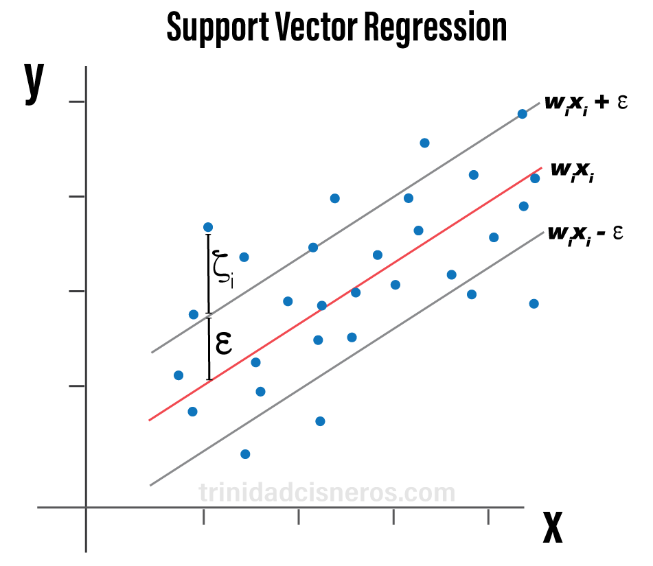

```python
img = os.path.join(path, 'static/images/svr/example1.png')
Image(filename=img)
```